# Introducción al ML: Aprendizaje Supervisado - Clasificación (Parte I)

5to año - Ingeniería en Sistemas de Información

UTN - Facultad Regional Villa María

*"We are drowning in information and starving for knowledge."*

```
                                    –Rutherford D. Roger
```

## Introducción al Aprendizaje Supervisado

Objetivo de máxima: predecir salidas $y$ a partir de una matriz de entrada:

$X = \begin{pmatrix} x_{1,1} & x_{1,2} & \cdots & x_{1,p} \\ x_{2,1} & x_{2,2} & \cdots & x_{2,p} \\ \vdots & \vdots & \ddots & \vdots \\ x_{n,1} & x_{n,2} & \cdots & x_{n,p} \end{pmatrix} $

Salidas:

$y = \begin{pmatrix} y_{1} \\ y_{2} \\ \vdots \\ y_{n} \end{pmatrix}$

Observación $X_i = \begin{pmatrix} x_{i,1} & x_{i,2} & \cdots & x_{i,p} \end{pmatrix}$

$X = \begin{pmatrix} \text{convexa} & \text{marrón} \\ \text{convexa} & \text{blanco} \\ \text{campana} & \text{blanco} \end{pmatrix} $

$y = \begin{pmatrix} \text{venenoso} \\ \text{comestible} \\ \text{comestible} \end{pmatrix}$

$y_i \in \{venenoso, comestible\}$

Objetivo: encontrar un modelo que pueda aprender cuándo un hongo es venenoso, para poder **generalizarlo** a hongos no vistos con anterioridad.

Vista general:

- Dado $X$, existen variables llamadas características, los cuales expresan aspectos de cada observación que pueden ser medidos o calculados.
- Los mismos influyen sobre otras llamadas variables de respuesta $y$.
- **Objetivo:** utilizar las entradas para **predecir** los valores de salida, para que nuestras predicciones $\hat{y}$ sean lo más cercanas posible a los valores verdaderos observados $y = f(X) + \epsilon$, donde $f(X)$ es la desconocida **función objetivo**.
- En el aprendizaje supervisado, el conjunto que incluye a $X$ e $y$ conforma el **dataset** $D_n = \{(X_1,y_1), (X_2,y_2),..., (X_n,y_n)\}$ compuesto por
  - $X_i \in \mathbb{R}^p$
  - $y_i \in \mathbb{R}$ o bien $y_i \in \{c_1, c_2, ..., c_n\}$ dependiendo de si se trata de un problema de **regresión** o de **clasificación**.
- Es "supervisado" porque el agente que aprende cuenta a priori con ejemplos correctos. Tras **entrenar** con ellos, el agente aprende a generalizar de tal modo de generar buenas predicciones sobre datos no observados.
- A partir de $D$, se distinguen el subconjunto de **datos de entrenamiento**, utilizados para adaptar el modelo y el subconjunto de **datos de test**, empleados para testear la capacidad de generalización del modelo para salidas no utilizadas en el entrenamiento.

[figure not shown]

Algunos ejemplos:

- Predecir el riesgo de una determinada enfermedad.
- Identificar una persona en una fotografía.
- Predecir si un correo es o no spam.
- Predecir el costo de una casa en base a sus características.

El aprendizaje supervisado se divide en dos categorías: regresión y clasificación.

- En problemas de regresión, **las salidas son variables continuas y ordenadas**. En otras palabras, una predicción $y=14.7$ es mayor que una predicción $y=12.5$ (esto no implica que la primera predicción sea más precisa que la segunda).
- En problemas de clasificación, por su parte, **las salidas son variables nominales discretas y no ordenadas**. Es decir que si las salidas posibles son "rojo" y "naranja", no es posible asumir un orden entre ellas como "rojo" > "naranja".

Se describen a continuación dos librerías principales de python para estos problemas

#### sci-kit learn

- Librería que contiene algoritmos de ML de regresión, clasificación, clustering, etc. así como utilidades como sets de datos de ejemplo.
- Define una interfaz común para todos los algoritmos. Método común a todos: `fit()`, adapta los datos de entrenamiento al modelo elegido. Dependiendo de la naturaleza de cada algoritmo, se definen distintos métodos comunes para cada uno de ellos.
- Los datos en sci-kit learn, en la gran mayoría de los casos, se asumen como un array de dos dimensiones, de forma X=[n_ejemplos, n_características]. Cada ejemplo es un ítem a ser procesado (ej: clasificado), pudiendo ser algo tan simple como una fila de excel a imágenes o videos.
- Por su parte, las características, cuya cantidad se establece a-priori, se usan para describir cada ítem de forma cuantitativa. Normalmente son representadas por valores reales, aunque también puede tratarse de valores booleanos o discretos.

Para el aprendizaje supervisado, scikit-learn provee la siguiente interfaz común de métodos

- `model.fit(X,y)` $\to$ modelo entrenado
- `model.predict(X)` $\to$ predicción $\hat{y}$ de $X$
- `model.predict_proba(X)` $\to$ probabilidad de cada clase para cada $X_i \in X$
- `model.score(X, y)` $\to$ tasa de aciertos (clasificación) o $R^2$ (regresión)
- `model.transform(X)` $\to$ $X'$

### sci-py

sci-py es una colección de librerías y algoritmos importante para machine learning. Normalmente el paquete a utilizar debe importarse por separado según necesidad. Algunos ejemplos:

```
 cluster                      : Vector Quantization / Kmeans
 fftpack                      : Discrete Fourier Transform algorithms
 integrate                    : Integration routines
 interpolate                  : Interpolation Tools
 io                           : Data input and output
 lib                          : Python wrappers to external libraries
 lib.blas                     : Wrappers to BLAS library
 lib.lapack                   : Wrappers to LAPACK library
 linalg                       : Linear algebra routines
 misc                         : Various utilities that don't have another home.
 ndimage                      : n-dimensional image package
 odr                          : Orthogonal Distance Regression
 optimize                     : Optimization Tools
 signal                       : Signal Processing Tools
 sparse                       : Sparse Matrices
 sparse.linalg                : Sparse Linear Algebra
 sparse.linalg.dsolve         : Linear Solvers
 sparse.linalg.dsolve.umfpack : :Interface to the UMFPACK library:
 sparse.linalg.eigen          : Sparse Eigenvalue Solvers
 sparse.linalg.eigen.arpack   : Eigenvalue solver using iterative methods.
 sparse.linalg.eigen.lobpcg   : Locally Optimal Block Preconditioned
                                  Conjugate Gradient Method (LOBPCG)
 spatial                      : Spatial data structures and algorithms
 special                      : Airy Functions

 stats                        : Statistical Functions
```

## Problemas de Regresión

[figure not shown]

[Fuente](https://ml.berkeley.edu/blog/posts/crash-course/part-5/)

## Problemas de Clasificación

[figure not shown]

[Fuente](https://ml.berkeley.edu/blog/posts/crash-course/part-5/)

- Al no existir un ordenamiento entre las clases, no es posible calcular una distancia entre $y$ e $\hat{y}$, tal como sí es posible en el caso de la regresión. Entonces, medidas como el error cuadrático medio utilizado en la regresión, $$MSE = \frac{1}{n} \sum^{n}_{i=1} (\hat{y}_i - y_i)^2$$ no resultan una buenas para entrenar o evaluar un clasificador.
- La medida más común es el **error rate**, dado por $$ \ell(y, \hat{y}) = \frac{1}{n} \sum_{i=1}^n I(y_i \neq \hat{y}_i)$$ donde $I(y_i \neq \hat{y}_i) = 1$ si nuestra predicción difiere de la salida real, mientras que $I(y_i \neq \hat{y}_i) = 0$ si nuestro modelo predijo correctamente la salida para cada observación $i$.

Vamos a inicializar nuestro entorno de trabajo en el Dataset Iris, tras presentarlo:

### Dataset Iris

"Iris" es un dataset que sirve como "Hello World" de ML. Consiste en un conjunto de ejemplos que contiene tres flores de Iris: setosa, virginica y versicolor. Las mismas están distribuídas en 50 ejemplos de cada flor, y sus características indican el largo y ancho tanto de su sépalo como de su pétalo, y también se especifica de qué clase de Iris se trata (setosa, virgínica o versicolor).

[figure not shown]

Fuente: David Gerster

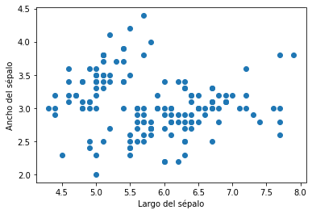

```python
%matplotlib inline

import matplotlib.pyplot as plt
from sklearn.datasets import load_iris  # sklearn.datasets contiene varios de los datasets clasicos de ML
from sklearn import neighbors

iris = load_iris()

X, y = iris.data, iris.target

# visualizamos como se relacionan el largo y el ancho del sepalo de las distintas flores
plt.scatter(X[:,0], X[:,1])
plt.xlabel('Largo del sépalo')  # xlabel le da un nombre al eje de las x
plt.ylabel('Ancho del sépalo')  # ylabel le da un nombre al eje de las y
plt.show()
```

```python
# tomamos los primeros dos features para mostrarlos mejor graficamente (el largo y el ancho del sepalo)
# (por eso el iris.data[:, :2])
X = iris.data[:, :2]
y = iris.target
```

Vamos a usar ambos features para entrenar nuestro modelo y graficar los puntos del dataset para el largo y ancho del sépalo, para cada tipo de flor

```python
# en primer lugar, vamos a ver las tres salidas posibles y los nombres de los features que elegimos

print(iris.target_names)
print(iris.feature_names)
```

```
['setosa' 'versicolor' 'virginica']
['sepal length (cm)', 'sepal width (cm)', 'petal length (cm)', 'petal width (cm)']
```

```python
# tras esto, vamos a seleccionar todos los puntos asociados a cada una de las salidas.
# Para ello vamos a restringir la matriz de entradas X a cada una de las entradas y
# salidas que nos interesan

# y==0 es una máscara que restringe X a aquellas filas asociadas con la salida 0 (setosa, según el
#nombre de los features), mientras que el 0 detrás de la "," restringe X a la columna 0
# (es decir, largo del sepalo)
X_setosa_largo_sepalo = X[y==0, 0]
print(X_setosa_largo_sepalo)
```

```
[5.1 4.9 4.7 4.6 5.  5.4 4.6 5.  4.4 4.9 5.4 4.8 4.8 4.3 5.8 5.7 5.4 5.1
 5.7 5.1 5.4 5.1 4.6 5.1 4.8 5.  5.  5.2 5.2 4.7 4.8 5.4 5.2 5.5 4.9 5.
 5.5 4.9 4.4 5.1 5.  4.5 4.4 5.  5.1 4.8 5.1 4.6 5.3 5. ]
```

```python
# hacemos esto mismo para las demas combinaciones
X_setosa_ancho_sepalo = X[y==0, 1]
X_virginica_largo_sepalo = X[y==1, 0]
X_virginica_ancho_sepalo = X[y==1, 1]
X_versicolor_largo_sepalo = X[y==2, 0]
X_versicolor_ancho_sepalo = X[y==2, 1]
```

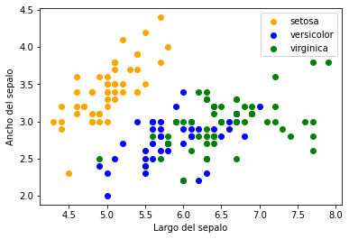

```python
# graficamos de acuerdo a la distribucion de los puntos

plt.scatter(X_setosa_largo_sepalo, X_setosa_ancho_sepalo, label=iris.target_names[0], color='orange')
plt.scatter(X_virginica_largo_sepalo, X_virginica_ancho_sepalo, label=iris.target_names[1], color='blue')
plt.scatter(X_versicolor_largo_sepalo, X_versicolor_ancho_sepalo, label=iris.target_names[2], color='green')

# legend coloca una caja con las leyendas correspondientes a los puntos del grafico
plt.legend(loc='best', numpoints=1)
plt.xlabel('Largo del sepalo')
plt.ylabel('Ancho del sepalo')

plt.show()
```

Notar que es también posible graficar utilizando directamente las restricciones sobre la matriz de datos $X$:

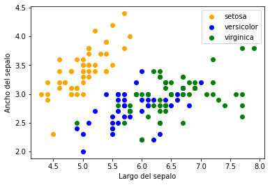

```python
plt.scatter(X[y==0, 0], X[y==0, 1], label=iris.target_names[0], color='orange')
plt.scatter(X[y==1, 0], X[y==1, 1], label=iris.target_names[1], color='blue')
plt.scatter(X[y==2, 0], X[y==2, 1], label=iris.target_names[2], color='green')

plt.legend(loc='best', numpoints=1)
plt.xlabel('Largo del sepalo')
plt.ylabel('Ancho del sepalo')

plt.show()
```

Antes de continuar, vamos a dividir nuestro conjunto de datos en entrenamiento y test

[figure not shown]

```python
from sklearn.model_selection import train_test_split

# Dividimos el conjunto en train, test
X_train, X_test, y_train, y_test = train_test_split(X, y, random_state=80, test_size=0.3)

# vemos los resultados de la mezcla...
print(y_test)
```

```
[0 0 0 1 0 1 1 0 0 0 2 1 1 0 2 1 0 1 0 0 0 2 2 1 1 0 2 1 1 2 0 1 0 1 2 1 0
 1 1 0 0 0 1 1 1]
```

Veamos cómo podemos implementar un clasificador kNN, utilizando la librería a alto nivel de scikit-learn.

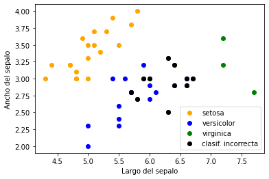

```python
# Instanciamos nuestro clasificador
clf_sk = neighbors.KNeighborsClassifier(n_neighbors=1, p=1)

clf_sk.fit(X_train,y_train)
y_hat = clf_sk.predict(X_test)

plt.scatter(X_test[y_test==0, 0], X_test[y_test==0, 1], label=iris.target_names[0], color='orange')
plt.scatter(X_test[y_test==1, 0], X_test[y_test==1, 1], label=iris.target_names[1], color='blue')
plt.scatter(X_test[y_test==2, 0], X_test[y_test==2, 1], label=iris.target_names[2], color='green')
plt.scatter(X_test[y_test!=y_hat, 0], X_test[y_test!=y_hat, 1],
                   label='clasif. incorrecta', c='black') # Agregamos las malas predicciones

plt.legend(loc='best', numpoints=1)
plt.xlabel('Largo del sepalo')
plt.ylabel('Ancho del sepalo')

plt.show()
```

```python
print('Tasa de aciertos: ', len(y_test[y_test==y_hat])/len(y_test))
```

```
Tasa de aciertos:  0.7333333333333333
```

También podemos obtener esta misma tasa a partir de los métodos de scikit-learn, lo cual nos ahorra el tener que hacerlo a mano.

```python
from sklearn.metrics import accuracy_score

print('Tasa de aciertos: ', accuracy_score(y_true=y_test, y_pred=y_hat))
```

```
Tasa de aciertos:  0.7333333333333333
```

## Validación cruzada con k-folds

- **Validación cruzada**: los datos son repetidamente separados en pares no superpuestos de entrenamiento y test, donde se ajusta un modelo separado para cada uno de dichos pares y se promedian los resultados.
- El método más común de validación cruzada es *k-folds*, donde los datos son separados en *k* pliegues (folds, normalmente son 5 o 10), donde para cada iteración se usa uno de los pliegues como conjunto de test y el resto como conjunto de entrenamiento, siendo la salida el promedio de los errores de todas las iteraciones.
- Este método asegura que todos los datos sean incluidos en el conjunto de test al menos una vez.
- Desventaja: aumenta muy considerablemente el costo computacional, haciendo que este método sea muy caro para datasets grandes.

[figure not shown]

- **Atención con el *data leakage***: al realizar la división, los datos de entrenamiento no deben contener datos que "filtren" información de las salidas del conjunto de test. Esto suele depender del dominio del problema, por ejemplo ver la [controversia sobre un artículo en la Nature sobre el uso de Deep Learning para predicción de terremotos](https://www.theregister.co.uk/2019/07/03/nature_study_earthquakes/) y sus correspondientes [posts](https://www.reddit.com/r/MachineLearning/comments/c4ylga/d_misuse_of_deep_learning_in_nature_journals/) de [debate](https://www.reddit.com/r/MachineLearning/comments/c5is9e/r_one_neuron_is_more_informative_than_a_deep/) en [reddit](https://old.reddit.com/r/MachineLearning/comments/c8zf14/d_was_this_quake_ai_a_little_too_artificial/).

## Ajuste de Híper-parámetros

Ahora que sabemos cómo evaluar un modelo, vamos a ver el que es uno de los temas más complejos en ML: el ajuste de los híper-parámetros.

- Quitando el caso de kNN, casi todo modelo internamente relaciona las entradas con las salidas por medio de **parámetros**, denotados comúnmente por $\theta = (\theta_1, \theta_2, \dots)$..
- Es en los parámetros que el modelo "guarda su aprendizaje" tras el entrenamiento, el cual suele consistir en ajustar iterativamente tales parámetros hasta que los mismos se estabilicen o permitan alcanzar alguna métrica.
- Por ejemplo, en una regresión lineal donde $\hat{y} = ax + b$, los parámetros son $a$ y $b$.
- Ahora bien, existen características que definen al modelo pero no son modificadas en el entrenamiento sino que se ubican en un nivel más alto de abstracción que los parámetros. Tales se conocen como **híper-parámetros**, denotados aquí por $\phi = (\phi_1, \phi_2, \dots)$.
- Los híper-parámetros son cruciales en el aprendizaje de un modelo, porque afectan cómo el mismo se desempeña y entrena. En el ejemplo de la regresión, un híper-parámetro $\phi_{grado}$ podría establecer el grado del polinomio, determinando a su vez la cantidad de parámetros utilizados en el aprendizaje. Ejemplo, con $\phi_{grado}=2$, la regresión estaría dada por $\hat{y} = ax^2 + bx + c$
- Pueden ir desde un nivel bajo de abstracción, por ejemplo $\phi$ puede representar la cantidad $k$ de vecinos en un algoritmo kNN, escalar más en la abstracción y representar la fórmula de distancia entre dos vectores, o bien escalar mucho más y representar qué modelo se utiliza.
- Es en el ajuste de híper-parámetros uno de los puntos principales donde ML **es más un arte que una ciencia**.
- Muchas veces los $\phi$ son establecidos por "decisiones de diseño" (ejemplo: "vamos a utilizar el siguiente modelo por su capacidad de explicar sus predicciones"); otras veces son establecidos a mano por prueba y error, y otras veces son ajustados a partir de algún método.
- Vamos a ver una forma de ajustarlos: separar un subconjunto del conjunto de entrenamiento para validación del modelo y utilizar Grid Search.

### Búsqueda en grilla (grid search)

- Método de optimización exhaustiva
- Dividimos el espacio de híper-parámetros en una grilla, y tomamos una muestra por cada casillero

[figure not shown]

### K-folds

[figure not shown]

Fuente: curso Convolutional Neural Networks for Visual Recognition (2016)

- Vamos a usar el fold amarillo, denominado **subconjunto de validación** para ajustar los híper-parámetros.
- Una vez determinados los mejores híper-parámetros, el conjunto de test debe entonces utilizarse una única vez para ver el resultado final de nuestro predictor.